# Part 1

Jane Huber

### Section A: Exploratory Data Analysis

The UC Irvine Law Review’s [“Taxed Out: Illegal Property Tax Assessments and the Epidemic of Tax Foreclosures in Detroit”](https://scholarship.law.uci.edu/ucilr/vol9/iss4/3/) explores the relationship between over-assessing a home and the ultimate foreclosure of that home. Let’s first explore overall assessment values–how do they look over time?

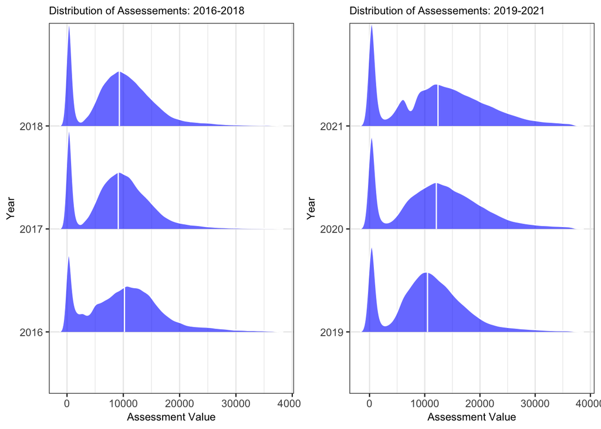

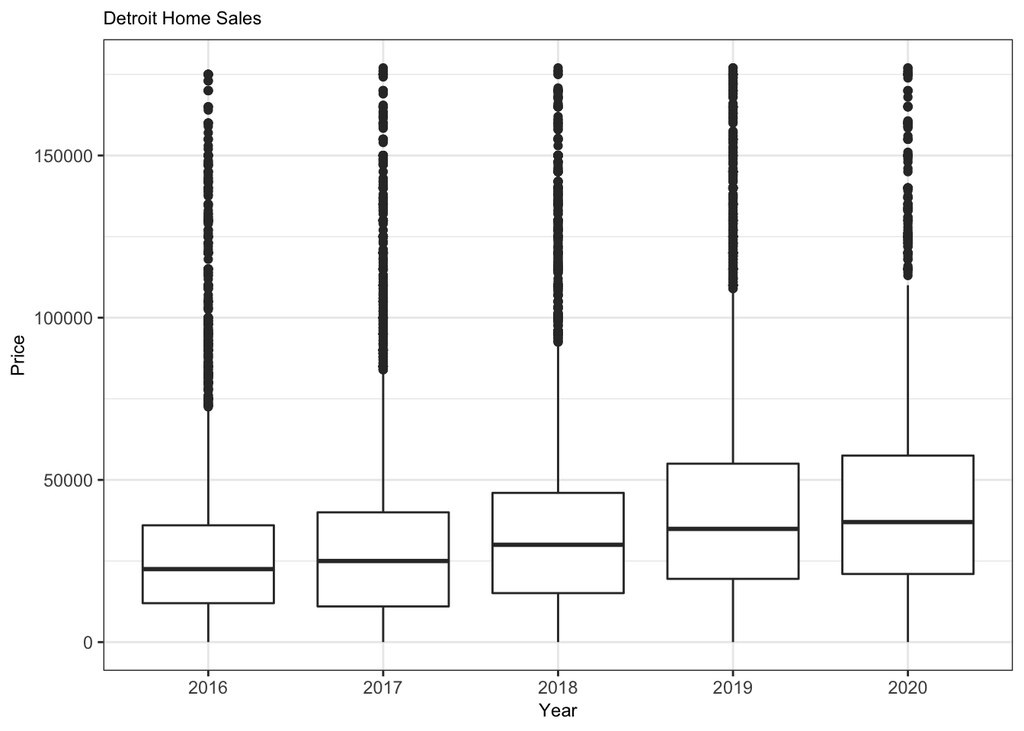

In this time frame, home sales increase over time. This underlines the corrective nature of the assessments to reduce compared to home values.

The Harris School of Public Policy at the University of Chicago’s The Center For Municipal Finance produced the report [“An Evaluation of Residential Property Tax Assessments in the City of Detroit, 2016-2018”](https://harris.uchicago.edu/files/evalrespropertytaxasdetroit20162018.pdf) emphasizes the reduction of the number of assessments higher than sales, but that it’s still too high. Let’s examine the ratio of sales to assessments next.

### Section B: Sales Ratio Study

```
## [1] "Filtered out non-arm's length transactions"
## [1] "Inflation adjusted to 2020"
```

Here, we can see how sale prices over the last few years compared to assessed value and explore the ratio of those differences.

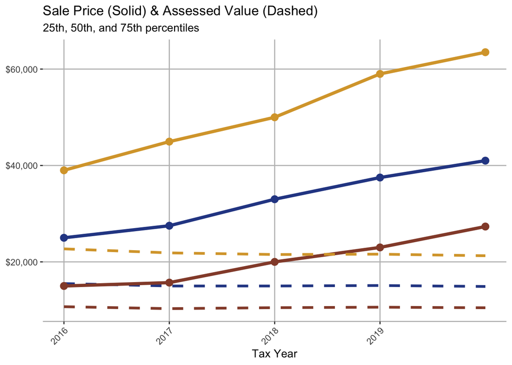

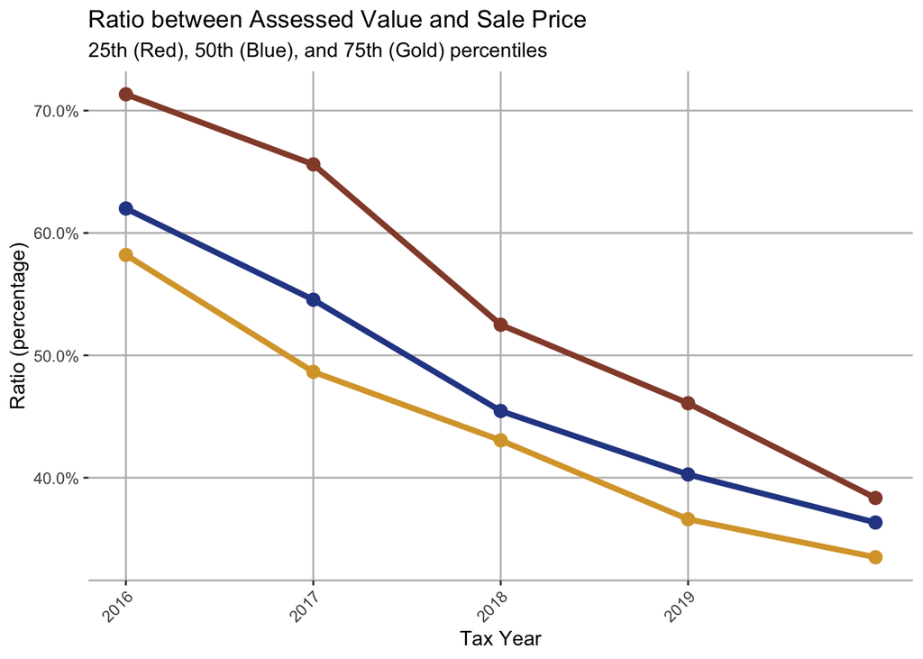

### Section C: Explore trends and relationships with property sales using simple regressions

| term | estimate | std.error | statistic | p.value |
| --- | --- | --- | --- | --- |
| (Intercept) | 30764.994 | 772.2978 | 39.8356627 | 0.000000e+00 |
| prop_class402 | -20398.533 | 2382.0754 | -8.5633447 | 1.149416e-17 |
| prop_class403 | 173839.590 | 2250.9971 | 77.2278152 | 0.000000e+00 |
| prop_class446 | 518154.486 | 23632.9780 | 21.9250610 | 1.070002e-105 |
| prop_class447 | 215773.994 | 52847.3461 | 4.0829674 | 4.458265e-05 |
| prop_class448 | 257498.762 | 19981.1666 | 12.8870735 | 6.753904e-38 |
| prop_class461 | -18810.800 | 37365.1561 | -0.5034316 | 6.146647e-01 |
| prop_class465 | -13564.994 | 52841.1414 | -0.2567127 | 7.974024e-01 |
| prop_class483 | 229156.008 | 19976.1070 | 11.4715049 | 2.131532e-30 |
| sale_date2017 | 2989.234 | 1001.6329 | 2.9843604 | 2.844071e-03 |

[output cut: 3 more lines]

### Section D: Explore trends and relationships with foreclosures using simple regressions

| term | estimate | std.error | statistic | p.value |
| --- | --- | --- | --- | --- |
| (Intercept) | -2.2745549 | 0.009359312 | -243.02587 | 0 |
| year_foreclosed2017 | -0.7442903 | 0.015949083 | -46.66665 | 0 |
| year_foreclosed2018 | -1.2457991 | 0.018787047 | -66.31160 | 0 |
| year_foreclosed2019 | -1.5993565 | 0.021424718 | -74.65006 | 0 |